# Your Document Title

### PRECIO, RENTABILIDAD Y VOLATILIDAD

A continuación, hemos realizado el mismo gráfico que el anterior per añadiendo la volatilidad.

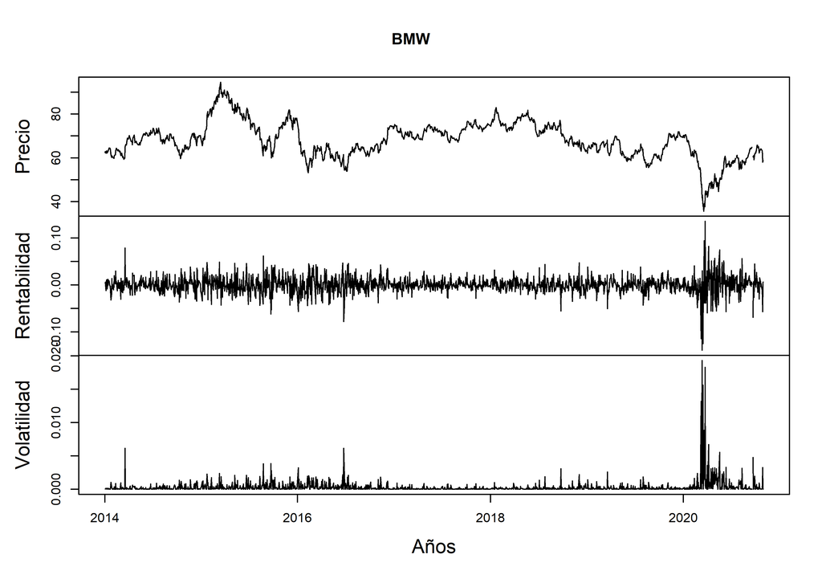

```r
  # Para el cálculo de la volatilidad utilizamos la rentabilidad al cuadrado
plot.zoo(cbind(bmw_x_data, ret_diar_bmw, ret_diar_bmw^2),
         main = "BMW",
         xlab = "Años", ylab = c("Precio", "Rentabilidad", "Volatilidad"))
```

De una manera intuitiva, la volatilidad es una medida de cuánto la rentabilidad fluctúa alrededor de su media. Es una medida del riesgo.

Por lo tanto, es importante, poder calcular esta volatilidad en cualquier instante, para analizar cómo varía con el tiempo y para predecir sus valores futuros.

Vemos como durante el los años ha habido ligeros aumentos de la volatilidad en el rendimiento de BMW pweo nada equiparable al causado por el covid.

Como hemos comentado antes, una estimación de la volatilidad es el rendimiento al cuadrado, para ello comprobaremos si es ruido blanco:

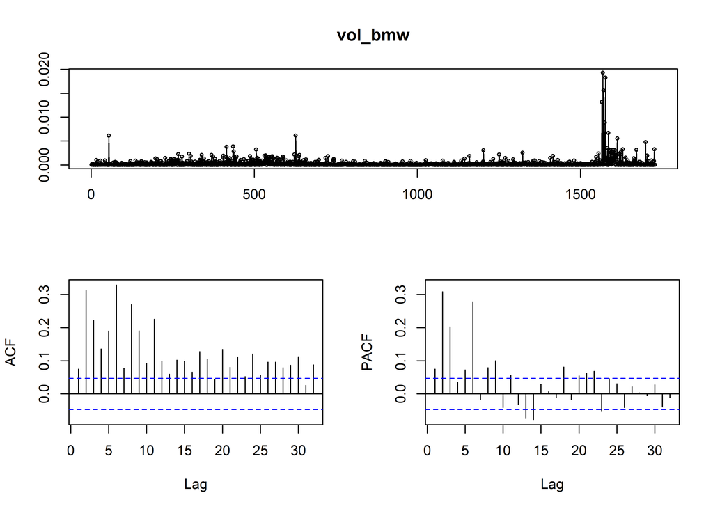

```r
  # Definimos la volatilidad
vol_bmw <- ret_diar_bmw^2

  # Observamos si es ruido blanco
tsdisplay(vol_bmw)
```

Vemos como la volatilidad no es ruido blanco…

### MODELOS GARCH

A título teórico, comenzaeremos con un modelo ARCH(1), estos modelos no son muy buenos en finanzas

```r
  # Generamos un modelo ARCH(1)
bmw_arch <- garchFit(~ 1 + garch(1, 0), data = ret_diar_bmw, trace = F)

summary(bmw_arch)
```

```
##
## Title:
##  GARCH Modelling
##
## Call:
##  garchFit(formula = ~1 + garch(1, 0), data = ret_diar_bmw, trace = F)
##
## Mean and Variance Equation:
##  data ~ 1 + garch(1, 0)
## <environment: 0x00000000216ed9c8>
##  [data = ret_diar_bmw]
##
## Conditional Distribution:
##  norm
##
## Coefficient(s):
##         mu       omega      alpha1
## 2.6597e-05  2.2775e-04  3.1833e-01
##
## Std. Errors:
##  based on Hessian
##
## Error Analysis:
##         Estimate  Std. Error  t value Pr(>|t|)
## mu     2.660e-05   3.908e-04    0.068    0.946
## omega  2.278e-04   1.029e-05   22.131  < 2e-16 ***
## alpha1 3.183e-01   4.542e-02    7.009  2.4e-12 ***
## ---
## Signif. codes:  0 '***' 0.001 '**' 0.01 '*' 0.05 '.' 0.1 ' ' 1
##
## Log Likelihood:
##  4584.49    normalized:  2.651527
##
## Description:
##  Sat Nov 28 13:12:40 2020 by user: jlopez
##
##
## Standardised Residuals Tests:
##                                 Statistic p-Value
##  Jarque-Bera Test   R    Chi^2  3877.096  0
##  Shapiro-Wilk Test  R    W      0.9369174 0
##  Ljung-Box Test     R    Q(10)  20.81008  0.02245751
##  Ljung-Box Test     R    Q(15)  28.7727   0.01720333
##  Ljung-Box Test     R    Q(20)  33.8583   0.02709933
##  Ljung-Box Test     R^2  Q(10)  316.5479  0
##  Ljung-Box Test     R^2  Q(15)  380.4377  0
##  Ljung-Box Test     R^2  Q(20)  473.5475  0
##  LM Arch Test       R    TR^2   230.9469  0
##
## Information Criterion Statistics:
##       AIC       BIC       SIC      HQIC
## -5.299583 -5.290118 -5.299589 -5.296082
```

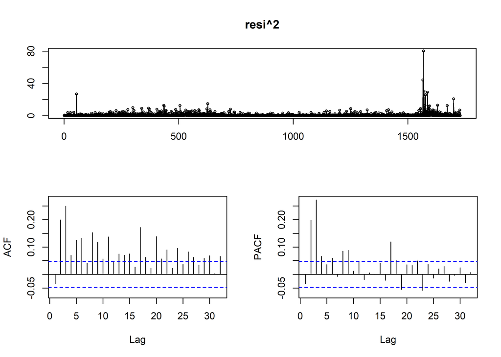

```r
  # Definimos los residuos
resi <- residuals(bmw_arch, standardize = T)

  # Creamos los residuos como xts ordenados
resi <- xts(resi,order.by = index(ret_diar_bmw))

  # ACF & PCF
tsdisplay(resi^2)
```

```r
  # Generamos un modelo GARCH(1, 1)
bmw_garch <- garchFit(~ 1 + garch(1, 1), data = ret_diar_bmw, trace = F)

summary(bmw_garch)
```

```
##
## Title:
##  GARCH Modelling
##
## Call:
##  garchFit(formula = ~1 + garch(1, 1), data = ret_diar_bmw, trace = F)
##
## Mean and Variance Equation:
##  data ~ 1 + garch(1, 1)
## <environment: 0x000000001d37a540>
##  [data = ret_diar_bmw]
##
## Conditional Distribution:
##  norm
##
## Coefficient(s):
##         mu       omega      alpha1       beta1
## 2.4520e-04  2.5351e-06  4.9427e-02  9.4283e-01
##
## Std. Errors:
##  based on Hessian
##
## Error Analysis:
##         Estimate  Std. Error  t value Pr(>|t|)
## mu     2.452e-04   3.367e-04    0.728  0.46643
## omega  2.535e-06   9.738e-07    2.603  0.00923 **
## alpha1 4.943e-02   7.901e-03    6.256 3.96e-10 ***
## beta1  9.428e-01   9.420e-03  100.092  < 2e-16 ***
## ---
## Signif. codes:  0 '***' 0.001 '**' 0.01 '*' 0.05 '.' 0.1 ' ' 1
##
## Log Likelihood:
##  4754.095    normalized:  2.749621
##
## Description:
##  Sat Nov 28 13:12:41 2020 by user: jlopez
##
##
## Standardised Residuals Tests:
##                                 Statistic p-Value
##  Jarque-Bera Test   R    Chi^2  765.8491  0
##  Shapiro-Wilk Test  R    W      0.9719083 0
##  Ljung-Box Test     R    Q(10)  21.16453  0.01997505
##  Ljung-Box Test     R    Q(15)  25.41795  0.04460435
##  Ljung-Box Test     R    Q(20)  31.23911  0.05211192
##  Ljung-Box Test     R^2  Q(10)  22.61902  0.01224364
##  Ljung-Box Test     R^2  Q(15)  23.95049  0.06593904
##  Ljung-Box Test     R^2  Q(20)  27.40125  0.1243478
##  LM Arch Test       R    TR^2   23.46486  0.02402888
##
## Information Criterion Statistics:
##       AIC       BIC       SIC      HQIC
## -5.494615 -5.481994 -5.494626 -5.489947
```

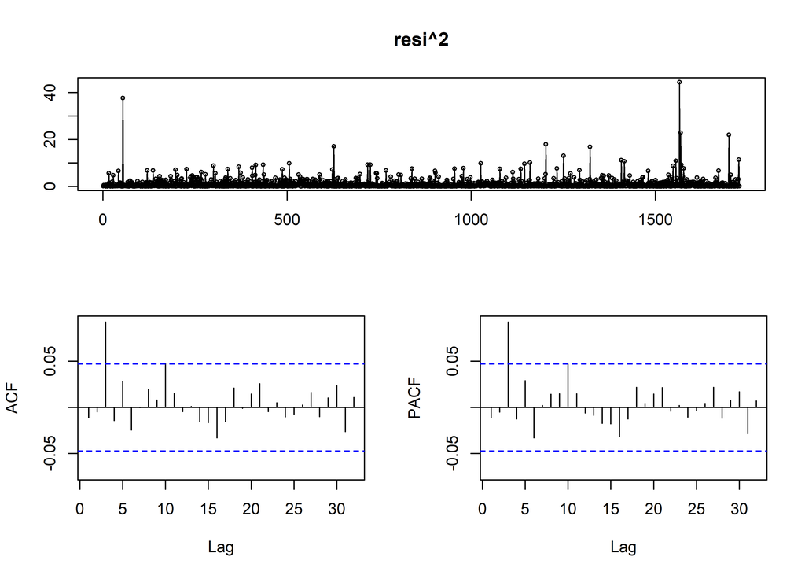

```r
  # Definimos los residuos
resi <- residuals(bmw_garch, standardize = T)

  # Creamos los residuos como xts ordenados
resi <- xts(resi,order.by = index(ret_diar_bmw))

  # ACF & PCF
tsdisplay(resi^2)
```

```r
  # plots
#plot(bmw_garch)
```

Podemos rechazar algua hipótesis nula, pero el LM ARCH aún no, por lo que debemos incorporar un modelo arma, para ello calcularemos con `auto.arima`

```r
bmw_arima <- auto.arima(ret_diar_bmw)

summary(bmw_arima)
```

```
## Series: ret_diar_bmw
## ARIMA(3,0,1) with zero mean
##
## Coefficients:
##           ar1     ar2     ar3     ma1
##       -0.7432  0.0673  0.1066  0.7724
## s.e.   0.0649  0.0298  0.0244  0.0614
##
## sigma^2 estimated as 0.0003066:  log likelihood=4542.44
## AIC=-9074.88   AICc=-9074.84   BIC=-9047.6
##
## Training set error measures:
##                        ME      RMSE        MAE MPE MAPE      MASE       ACF1
## Training set -3.22269e-05 0.0174894 0.01214382 NaN  Inf 0.7134847 0.00234568
```

Ahora sabemos que tenemos que utilizar un arma(3, 1)

```r
  # Generamos un modelo ARMA(3, 1) & GARCH(2, 2)
bmw_garch_ar <- garchFit(~ arma(3, 1) + garch(2, 2), data = ret_diar_bmw, trace = F)

summary(bmw_garch_ar)
```

```
##
## Title:
##  GARCH Modelling
##
## Call:
##  garchFit(formula = ~arma(3, 1) + garch(2, 2), data = ret_diar_bmw,
##     trace = F)
##
## Mean and Variance Equation:
##  data ~ arma(3, 1) + garch(2, 2)
## <environment: 0x000000001de1d170>
##  [data = ret_diar_bmw]
##
## Conditional Distribution:
##  norm
##
## Coefficient(s):
##          mu          ar1          ar2          ar3          ma1        omega
##  3.3220e-04  -3.1229e-01   5.5991e-02   5.6598e-02   3.8604e-01   3.9692e-06
##      alpha1       alpha2        beta1        beta2
##  6.4738e-02   1.8779e-02   2.0034e-01   7.0424e-01
##
## Std. Errors:
##  based on Hessian
##
## Error Analysis:
##          Estimate  Std. Error  t value Pr(>|t|)
## mu      3.322e-04   4.663e-04    0.712 0.476219
## ar1    -3.123e-01   2.427e-01   -1.287 0.198127
## ar2     5.599e-02   3.206e-02    1.746 0.080771 .
## ar3     5.660e-02   2.599e-02    2.178 0.029418 *
## ma1     3.860e-01   2.420e-01    1.595 0.110634
## omega   3.969e-06   1.641e-06    2.419 0.015556 *
## alpha1  6.474e-02   1.819e-02    3.559 0.000372 ***
## alpha2  1.878e-02   2.133e-02    0.881 0.378544
## beta1   2.003e-01   1.617e-01    1.239 0.215384
## beta2   7.042e-01   1.528e-01    4.607 4.08e-06 ***
## ---
## Signif. codes:  0 '***' 0.001 '**' 0.01 '*' 0.05 '.' 0.1 ' ' 1
##
## Log Likelihood:
##  4762.108    normalized:  2.754255
##
## Description:
##  Sat Nov 28 13:12:42 2020 by user: jlopez
##
##
## Standardised Residuals Tests:
##                                 Statistic p-Value
##  Jarque-Bera Test   R    Chi^2  756.4337  0
##  Shapiro-Wilk Test  R    W      0.9721469 0
##  Ljung-Box Test     R    Q(10)  6.490973  0.7724666
##  Ljung-Box Test     R    Q(15)  10.77811  0.7681595
##  Ljung-Box Test     R    Q(20)  17.05047  0.649694
##  Ljung-Box Test     R^2  Q(10)  18.14677  0.0525378
##  Ljung-Box Test     R^2  Q(15)  19.65249  0.1856725
##  Ljung-Box Test     R^2  Q(20)  23.39519  0.269809
##  LM Arch Test       R    TR^2   18.84513  0.09233511
##
## Information Criterion Statistics:
##       AIC       BIC       SIC      HQIC
## -5.496944 -5.465392 -5.497010 -5.485273
```

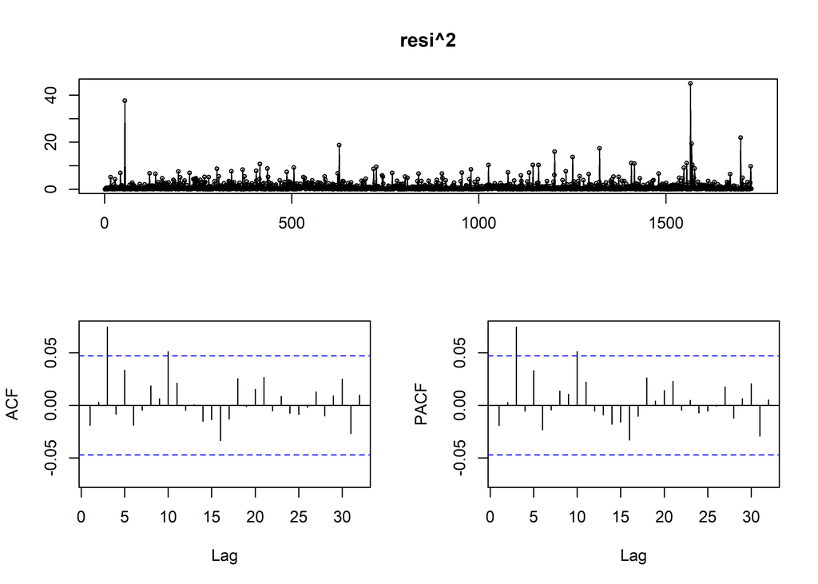

```r
  # Definimos los residuos
resi <- residuals(bmw_garch_ar, standardize = T)

  # Creamos los residuos como xts ordenados
resi <- xts(resi,order.by = index(ret_diar_bmw))

  # ACF & PCF
tsdisplay(resi^2)
```

Ahora si tenemos el modelo correcto!

### Volatilidad de BMW

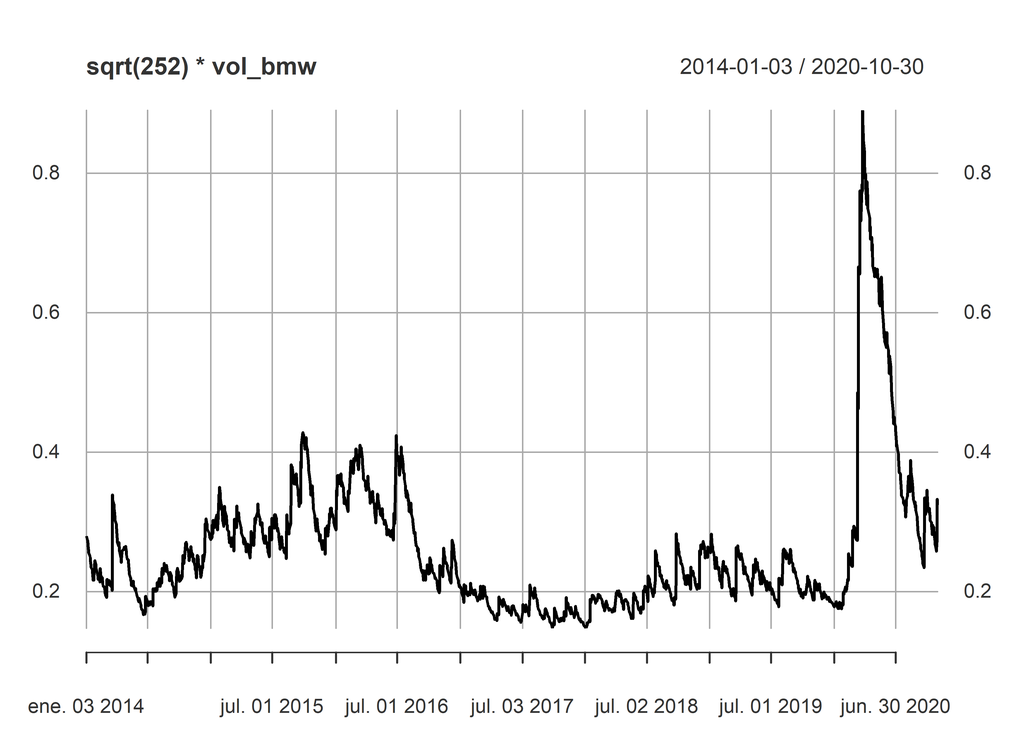

```r
  # Calculamos la volatilidad
vol_bmw <- volatility(bmw_garch)

  # La pasamos a un xts
vol_bmw <- xts(vol_bmw, order.by = index(ret_diar_bmw))

  # Graficamos el resultdo, utilizamos la raíz de 252 porque es el número de días de un año bursátil
plot(sqrt(252) * vol_bmw)
```

Podemos observar de manera clara, como aumentó la volatilidad entre el 2014 y el 2016 debido al *diselgate* y como en marzo de 2020 se disparó el riesgo debido a la situaciónd de incertidumbre que vivimos durante el covid.

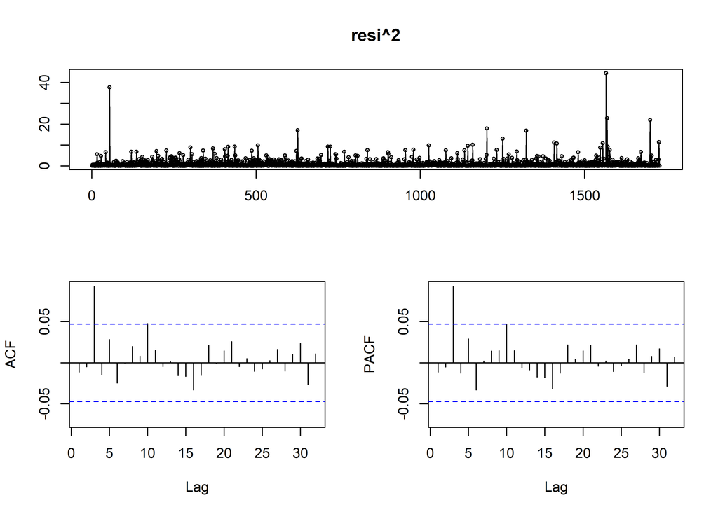

```r
  # Calculamos los residuos
resi=residuals(bmw_garch, standardize = T)

  # Los convertimos a un objeto xts
resi=xts(resi, order.by = index(ret_diar_bmw))

   # ACF & PCF
tsdisplay(resi^2)
```

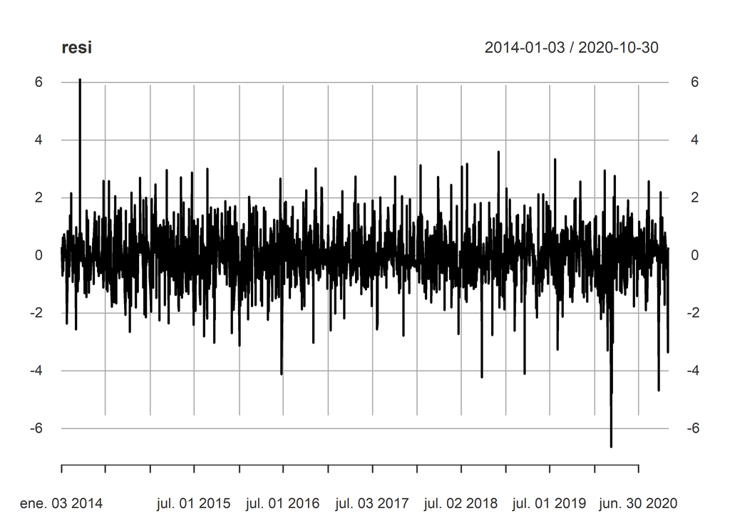

```r
  # Graficamos los residuos
plot(resi)
```

### PREDICCIÓN

Dado que la predicción no funciona correctamente con el mejor modelo arma(3, 1) garch(2, 2) realizaremos la predicción con el garch(1, 1)

```r
  # Calculamos la predicción
predict(bmw_garch)
```

```
##    meanForecast  meanError standardDeviation
## 1  0.0002451986 0.01993832        0.01993832
## 2  0.0002451986 0.01992465        0.01992465
## 3  0.0002451986 0.01991108        0.01991108
## 4  0.0002451986 0.01989761        0.01989761
## 5  0.0002451986 0.01988423        0.01988423
## 6  0.0002451986 0.01987095        0.01987095
## 7  0.0002451986 0.01985776        0.01985776
## 8  0.0002451986 0.01984466        0.01984466
## 9  0.0002451986 0.01983166        0.01983166
## 10 0.0002451986 0.01981875        0.01981875
```

A continuación, graficaremos el intervalo de confianza de la volatilidad.

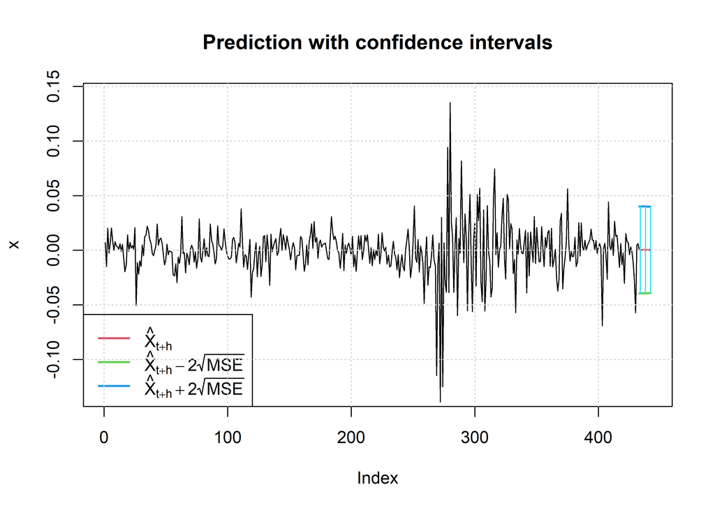

```
##    meanForecast  meanError standardDeviation lowerInterval upperInterval
## 1  0.0002451986 0.01993832        0.01993832   -0.03963144    0.04012184
## 2  0.0002451986 0.01992465        0.01992465   -0.03960411    0.04009451
## 3  0.0002451986 0.01991108        0.01991108   -0.03957697    0.04006737
## 4  0.0002451986 0.01989761        0.01989761   -0.03955002    0.04004042
## 5  0.0002451986 0.01988423        0.01988423   -0.03952327    0.04001366
## 6  0.0002451986 0.01987095        0.01987095   -0.03949670    0.03998710
## 7  0.0002451986 0.01985776        0.01985776   -0.03947032    0.03996072
## 8  0.0002451986 0.01984466        0.01984466   -0.03944413    0.03993452
## 9  0.0002451986 0.01983166        0.01983166   -0.03941812    0.03990852
## 10 0.0002451986 0.01981875        0.01981875   -0.03939230    0.03988270
```

```r
  # Ploteamos la predicción estableciendo el criterio de 2 veces el error estándar
predict(bmw_garch, n.ahead = 10, plot = TRUE, crit_val = 2)
```

Como podemos observar, tenemos el efecto del coronavirus antes de index = 300, llegando a valores de casi el 15%, lo que supone una alta incertidumbre, pero según nuestra previsión podemos estar en los valores de antes de marzo, por lo que hemos experimentado una reducción de la volatilidad.

Para ver esto más claro, hemos decidido realizar el mismo gráfico pero a 180 días y con un intervalo de confianza del 90%

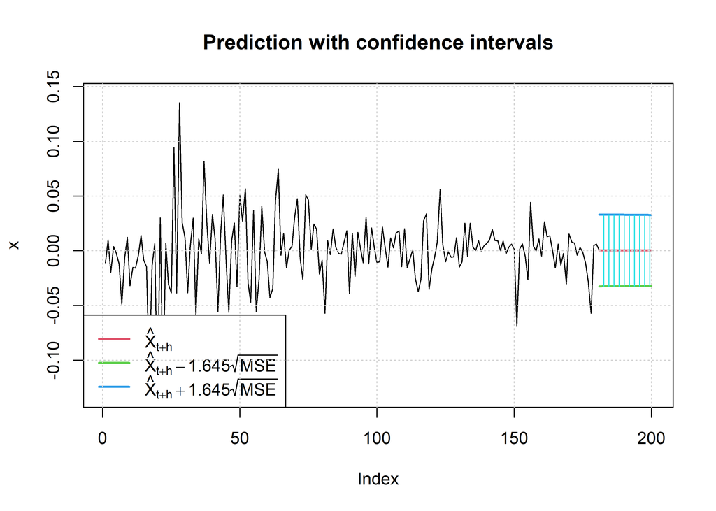

```
##    meanForecast  meanError standardDeviation lowerInterval upperInterval
## 1  0.0002451986 0.01993832        0.01993832   -0.03255042    0.03304082
## 2  0.0002451986 0.01992465        0.01992465   -0.03252794    0.03301834
## 3  0.0002451986 0.01991108        0.01991108   -0.03250562    0.03299602
## 4  0.0002451986 0.01989761        0.01989761   -0.03248346    0.03297386
## 5  0.0002451986 0.01988423        0.01988423   -0.03246145    0.03295185
## 6  0.0002451986 0.01987095        0.01987095   -0.03243960    0.03293000
## 7  0.0002451986 0.01985776        0.01985776   -0.03241791    0.03290831
## 8  0.0002451986 0.01984466        0.01984466   -0.03239637    0.03288676
## 9  0.0002451986 0.01983166        0.01983166   -0.03237498    0.03286538
## 10 0.0002451986 0.01981875        0.01981875   -0.03235374    0.03284414
## 11 0.0002451986 0.01980593        0.01980593   -0.03233266    0.03282305
## 12 0.0002451986 0.01979320        0.01979320   -0.03231172    0.03280212
## 13 0.0002451986 0.01978056        0.01978056   -0.03229093    0.03278133
## 14 0.0002451986 0.01976802        0.01976802   -0.03227029    0.03276069
## 15 0.0002451986 0.01975556        0.01975556   -0.03224980    0.03274020
## 16 0.0002451986 0.01974319        0.01974319   -0.03222946    0.03271985
## 17 0.0002451986 0.01973091        0.01973091   -0.03220926    0.03269965
## 18 0.0002451986 0.01971871        0.01971871   -0.03218920    0.03267960
## 19 0.0002451986 0.01970661        0.01970661   -0.03216928    0.03265968
## 20 0.0002451986 0.01969459        0.01969459   -0.03214951    0.03263991
```

```r
  # Ploteamos la predicción estableciendo unos intervalos de confianza del 90% y 180 días
predict(bmw_garch, n.ahead = 20, plot = TRUE, conf = .9, nx = 180)
```

De esta manera, podemos observar como se ha reducido de manera considerable la volatilidad del activo y establecemos unas bandas de fluctuación entre el -0.03 y el 0.03.

## Plantear un modelo VAR mensual entre los dos activos

```r
  # Pasamos a mensual seleccionando el precio ajustado, es decir, la columna 6
rBmw <- monthlyReturn(bmw_data[, 6])

  # Pasamos a mensual seleccionando el precio ajustado, es decir, la columna 6
rVow <- monthlyReturn(vow_data[, 6])
```

Como podemos observar en las bases de datos, pasamos de mes en mes, en vez de ser diario. El siguiente paso es generar un vector con la información de los activos:

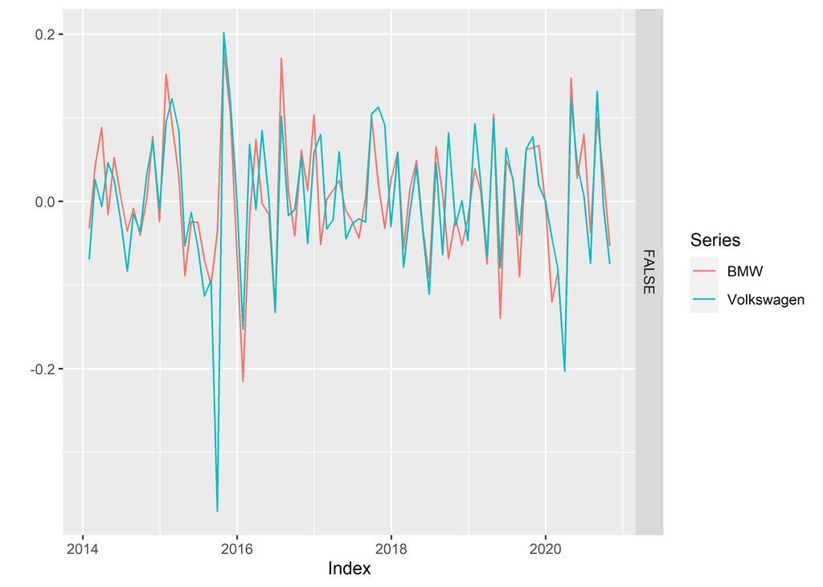

```r
  # Generamos nuestro vector
vY <- cbind(rBmw, rVow)
colnames(vY) <- c("BMW", "Volkswagen")

  # Ploteamos el precio mensual
autoplot(vY, facets = F)
```

Como podemos observar, ambos activos fluctuan de manera muy siimilar, sin embargo, vemos como a finales del 2015 el efecto del *dieselgate* afectó mucho más a Volkswagen que a BMW.

### Selección del modelo

Dado que la serie no es estacionaria realizamos la transformación…

```r
  # Volvemos a cargar los datos para evitar problemas
getSymbols('BMW.DE', from='2014-01-01', to='2020-11-01', warnings = F)
```

```
## [1] "BMW.DE"
```

```r
getSymbols('VOW.DE', from='2014-01-01', to='2020-11-01', warnings = F)
```

```
## [1] "VOW.DE"
```

```r
  # Realizamos la transformación
bmw_ret <- diff(log(Ad(BMW.DE)))
vow_ret <- diff(log(Ad(VOW.DE)))

  # Utilizamos la columna del precio ajustado
bmw_ret <- to.monthly(bmw_ret)$bmw_ret.Close
vow_ret <- to.monthly(vow_ret)$vow_ret.Close

  # Generamos nuestro vector
vY <- cbind(bmw_ret, vow_ret)
colnames(vY) <- c("BMW","Volkswagen") #le ponemos nombres

  # Omitimos los na
vY <- na.omit(vY)
```

```r
VARselect(vY)
```

```
## $selection
## AIC(n)  HQ(n)  SC(n) FPE(n)
##      1      1      1      1
##
## $criteria
##                    1             2             3             4             5
## AIC(n) -1.714680e+01 -1.713286e+01 -1.705246e+01 -1.704752e+01 -1.695321e+01
## HQ(n)  -1.707127e+01 -1.700698e+01 -1.687623e+01 -1.682093e+01 -1.667627e+01
## SC(n)  -1.695708e+01 -1.681666e+01 -1.660977e+01 -1.647836e+01 -1.625756e+01
## FPE(n)  3.575032e-08  3.626489e-08  3.933200e-08  3.958195e-08  4.359221e-08
##                    6             7             8             9            10
## AIC(n) -1.689528e+01 -1.684113e+01 -1.675698e+01 -1.666501e+01 -1.659549e+01
## HQ(n)  -1.656799e+01 -1.646348e+01 -1.632898e+01 -1.618666e+01 -1.606678e+01
## SC(n)  -1.607315e+01 -1.589251e+01 -1.568189e+01 -1.546343e+01 -1.526743e+01
## FPE(n)  4.633917e-08  4.913251e-08  5.375560e-08  5.937304e-08  6.424221e-08
```

Estimamos con el modelo

```r
modelo <- VAR(vY)

summary(modelo)
```

```
##
## VAR Estimation Results:
## =========================
## Endogenous variables: BMW, Volkswagen
## Deterministic variables: const
## Sample size: 81
## Log Likelihood: 475.483
## Roots of the characteristic polynomial:
## 0.1904 0.06776
## Call:
## VAR(y = vY)
##
##
## Estimation results for equation BMW:
## ====================================
## BMW = BMW.l1 + Volkswagen.l1 + const
##
##                Estimate Std. Error t value Pr(>|t|)
## BMW.l1        -0.103936   0.159551  -0.651    0.517
## Volkswagen.l1  0.037153   0.125712   0.296    0.768
## const         -0.002347   0.001572  -1.493    0.139
##
##
## Residual standard error: 0.01391 on 78 degrees of freedom
## Multiple R-Squared: 0.006088,    Adjusted R-squared: -0.0194
## F-statistic: 0.2389 on 2 and 78 DF,  p-value: 0.7881
##
##
## Estimation results for equation Volkswagen:
## ===========================================
## Volkswagen = BMW.l1 + Volkswagen.l1 + const
##
##                Estimate Std. Error t value Pr(>|t|)
## BMW.l1        -0.286629   0.199538  -1.436    0.155
## Volkswagen.l1  0.226613   0.157218   1.441    0.153
## const         -0.003036   0.001966  -1.544    0.127
##
##
## Residual standard error: 0.01739 on 78 degrees of freedom
## Multiple R-Squared: 0.03019, Adjusted R-squared: 0.005327
## F-statistic: 1.214 on 2 and 78 DF,  p-value: 0.3025
##
##
##
## Covariance matrix of residuals:
##                  BMW Volkswagen
## BMW        0.0001934  0.0001704
## Volkswagen 0.0001704  0.0003025
##
## Correlation matrix of residuals:
##               BMW Volkswagen
## BMW        1.0000     0.7047
## Volkswagen 0.7047     1.0000
```

Calculamos la causalidad de granger:

```r
causality(modelo)
```

```
## $Granger
##
##  Granger causality H0: BMW do not Granger-cause Volkswagen
##
## data:  VAR object modelo
## F-Test = 2.0634, df1 = 1, df2 = 156, p-value = 0.1529
##
##
## $Instant
##
##  H0: No instantaneous causality between: BMW and Volkswagen
##
## data:  VAR object modelo
## Chi-squared = 26.878, df = 1, p-value = 2.167e-07
```

Tras realizar el test de causalidad no podemos rechazar la hipótesis nula de NO causalidad, por lo que no tiene sentido continuar…